### Monitoria 9 - Heterocedasticidade

Nome: Lucas Martins de Farias Fernandes  
Email: Lucasmffernandes@gmail.com

```r
#setup
library(tidyverse)
library(wooldridge)
library(car)
library(stargazer)

#install.packages("lmtest")
library(lmtest)
```

#### **1. Heteroscedasticidade**

Ao estudar a variância dos estimadores do MQO adotamos a hipótese de homoscedasticidade, que significa que a variância do erro não observável, u, condicional nas variáveis explicativas, é constante. Formalizando:

**Homoscedasticidade.**

> O erro u tem a mesma variância dada a quaisquer valores das variáveis explicativas. Em outras palavras, $Var(u|x_1,...,x_k) = \sigma^2$

Essa hipótese é quebrada sempre que a variância dos fatores não observáveis muda ao longo de diferentes segmentos da população. Vejamos um exemplo de heteroscedasticidade:

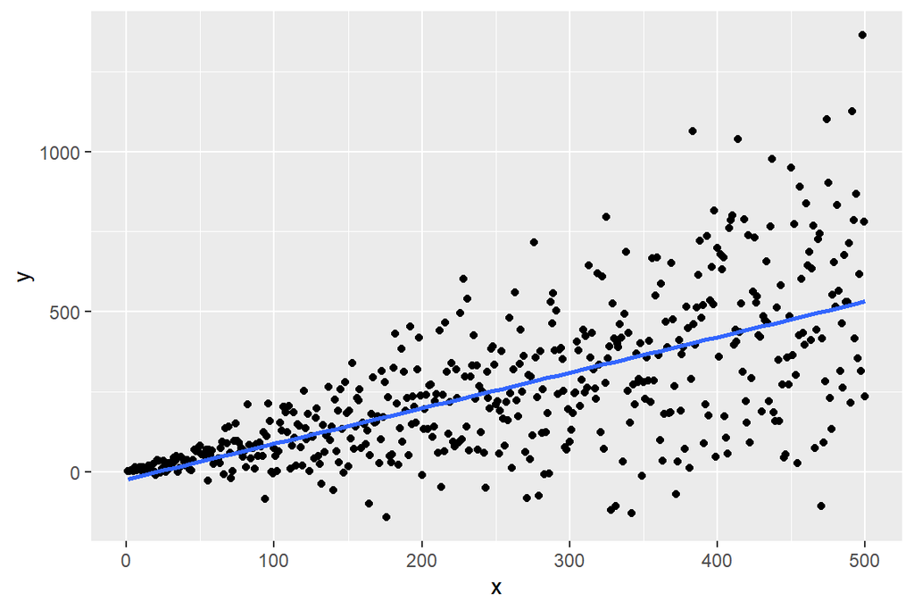

```r
set.seed(905)

# gerando dados com heterocedasticidade:
dados_hetero <- tibble(x = 1:500) %>%
  mutate(
    y = rnorm(n = 500, mean = x, sd = 0.6 * x)
  )

#Plotando dados e reg
dados_hetero %>%
  ggplot(aes(x,y)) +
  geom_point() +
  geom_smooth(method = "lm",alpha = 0)
```

Percebe-se que no gráfico, quanto maior x, maior é a dispersão dos valores ao redor da reta de regressão, ou seja, a variância de y aumenta conforme x aumenta. Utilizamos a hipótese de homoscedasticidade para justificar a utilização dos testes t e F. Sobre heteroscedasticidade, as estatísticas t não seguem uma distribuição t e o mesmo será verdade para F, ou seja, as estatísticas que utilizamos nos testes de hipóteses não são mais válidas. Devemos, nesse caso, ajustar nosso modelo para tornar as estatísticas válidas.

#### **2. O teste para heteroscedasticidade.**

Nem sempre a análise gráfica é o suficiente para identificar o problema de heteroscedasticidade. Para isso, podemos realizar testes estatísticos, que detectam a presença. Focaremos aqui no teste de Breusch-Pagan, ou BP, que é o mais comum. Suponha que queremos regredir o seguinte modelo teórico:

$y = \beta_0 + \beta_1 x_1 + \beta_2 x_2 + ... + \beta_k x_k + u$

Vamos assumir que as hipóteses 1 a 4, são válidas e, portanto, não ha viés no nosso modelo. Queremos testar, se a hipótese nula de homoscedasticidade é verdadeira:

$H_0: Var(u|x_1,x_2,...,x_k) = \sigma^2$

Ou seja, presumimos que os erros são heteroscedasticos. Como assumimos que a hipótese 4, $E(u|x_1,...,x_k) = 0$, é válida, em outras palavras, supomos que u tem esperança condicional 0, $Var(u|x_1,x_2,...,x_k) = E(u^2|_1,x_2,...,x_k)$. Dessa forma, podemos escrever a hipótese nula de homoscedasticidade da seguinte forma:

$H_0: E(u^2|_1,x_2,...,x_k) = E(u^2) = \sigma^2$

Isso mostra que para testar se há presença de heteroscedasticidade, devemos verificar se $u^2$ está relacionado a uma ou mais variável explicativa. Para isso, regredimos uma regressão com o quadrado dos erros como variável dependente:

$u^2 = \delta_0 + \delta_1 x_1 + \delta_2 x_2 + ... + \delta_k x_k + v$

Para verificar a nula que:

$H_0: \delta_1 = \delta_2 = ... = \delta_k =0$

Lembre-se que nunca conhecemos os erros verdadeiros do modelo, portanto, iremos na prática estimar a relação entre os resíduos. Sendo assim, de forma análoga, testaremos na prática:

$\hat{u}^2 = \delta_0 + \delta_1 x_1 + \delta_2 x_2 + ... + \delta_k x_k + v$

Vamos agora para um exemplo prático. Supondo o que queremos estimar o modelo:

$price = lotsize + sqrft + bdrms + u$

Calculando:

```r
dados_1 <- wooldridge::hprice1

modelo <- lm(price ~ lotsize + sqrft + bdrms,dados_1)
```

Regredido o modelo, partimos para o teste:

**1º** Obtenha os quadrados dos resíduos, $\hat{u^2}$ do modelo em questão:

```r
resid_sq <- resid(modelo)^2
```

**2º** Registre o R quadrado, $R_{\hat{u^2}}^2$, da regressão com os quadrados dos resíduos como variável dependente, contra as variáveis dependentes do modelo original. Estimando:

$u^2 = \delta_0 + \delta_1 lotsize + \delta_2 sqrft + \delta_3 bdrms$

```r
mod_resid <- lm(resid_sq ~ lotsize + sqrft + bdrms,dados_1)

r_sq <- summary(mod_resid)$r.squared
```

Repare que ao registrar o R2 dessa regressão estamos verificando o quando as varáveis independentes explicam dos resíduos. Se o R2 é “significativo”, há presença de heteroscedasticidade. Para verificar isso, aplicamos o teste LM…

**3º** Calcule a estatística LM:

$LM = n R_{\hat{u^2}}^2$

```r
LM = nrow(dados_1) * r_sq
LM
```

```
## [1] 14.09239
```

A estatística LM segue uma distribuição qui-quadrado, $\chi^2_{k}$. Com isso, o valor de uma distribuição $\chi^2_{k}$ com 3 graus de liberdade a um nível de sig de 5% é dado por:

```r
qchisq(1-0.05,df = 3)
```

```
## [1] 7.814728
```

Como LM = 14.09 > 7.8, rejeitamos a hipótese nula, ou seja, há evidências de heteroscedasticidade. Evidentemente, na prática, não precisamos realizar o teste na mão. A função bptest() do pacote lmtest, permite realizar o teste automaticamente:

```r
bptest(modelo)
```

```
##
##  studentized Breusch-Pagan test
##
## data:  modelo
## BP = 14.092, df = 3, p-value = 0.002782
```

#### **3.1 Inferência robusta em relação à heteroscedasticidade.**

Identificado o problema, devemos encontrar uma forma de tornas as estatísticas válidas na presença de heteroscedasticidade. Em certos casos, alterar a forma funcional do modelo, utilizando log por exemplo, é suficiente para resolver o problema. Porém, nem sempre isso será possível. Mas isso não significa que devemos deixar de lado o modelo MQO, existem métodos capazes de gerar estatísticas válidas mesmo na presença de heteroscedasticidade. Esses métodos são chamados de procedimentos robustos à heteroscedasticidade (Capítulo 8 do Wooldridge). Vejamos como funciona, usualmente, calculamos a matriz varcov da seguinte forma:

$varcov(\hat{\beta}) = (X'X)^{-1}X'E[uu']X(X'X)^{-1}$

sob a hipótese de homoscedasticidade $E[uu'] = \sigma^2I$. Com isso chegamos na forma usual, simplificada, de calcular a matriz:

$varcov(\hat{\beta}) = \sigma^2(X'X)^{-1}$

Quando há heterocedasticidade a simplificação anterior não é possível. Devemos levar em conta que $E[uu'] = \sigma^2\Omega$, onde:

$$\mathbf{\sigma^2\Omega} = \sigma^2\left[\begin{array}{rrr}\omega_1 & \cdots & 0 \\\vdots & \ddots & \vdots \\0 & \cdots &\omega_n\end{array}\right] = \left[\begin{array}{rrr}{\sigma_{1}}^2 & \cdots & 0 \\\vdots & \ddots & \vdots \\0 & \cdots &{\sigma_{i}}^2\end{array}\right]$$

Substituindo na equação (1) temos:

$varcov(\hat{\beta}) = (X'X)^{-1}X'\sigma^2\Omega X(X'X)^{-1}$

Se o tipo de heterocedasticidade,$\Omega$, é conhecido podemos utilizar a equação (3) para corrigir a heterocedasticidade. Se não, devemos adotar técnicas de estimação que requerem a formulação de $\Omega$. Podemos utilizar o estimador proposto por White (1980), onde $E[uu']=diag[{e_{i}^2]}$, substituindo na eq. (1) temos:

$HC0 = (X'X)^{-1}X'diag[{e_{i}^2]}X(X'X)^{-1}$

Como demonstrado por White (1980), $HC0$ é um estimador válido de $Var(\hat{\beta_j})$ na presença de heteroscedasticidade.

#### **3.3 Finalmente, na prática.**

Vamos estimar o seguinte modelo, do exemplo 8.2 do Wooldridge:

$$\widehat{cumgpa} = \beta_0 + \beta_1 sat + \beta_2 hsperc + \beta_3 tothrs +\beta_4 female + \beta_5 black + \beta_6 white$$

```r
dados_2 <- wooldridge::gpa3 %>%
  filter(spring == 1)

modelo_hetero <- lm(cumgpa ~ sat + hsperc + tothrs + female + black + white,data = dados_2)
```

Realizando o teste BP:

```r
modelo_hetero %>% bptest()
```

```
##
##  studentized Breusch-Pagan test
##
## data:  .
## BP = 44.557, df = 6, p-value = 5.732e-08
```

Como o pvalor é baixo, rejeitamos a hipótese nula de homoscedasticidade. Há, portanto, evidência de heteroscedasticidade no modelo. A função hccm() do pacote car, permite calcular a matriz covariância robusta a heteroscedasticidade, $HC0$, apresentada anteriormente:

```r
hccm(modelo_hetero,type = "hc0")
```

```
##               (Intercept)           sat        hsperc        tothrs
## (Intercept)  4.776834e-02 -3.303536e-05 -1.668383e-04 -3.550256e-05
## sat         -3.303536e-05  3.598278e-08  7.302412e-08  5.742166e-09
## hsperc      -1.668383e-04  7.302412e-08  1.972066e-06  1.333911e-07
## tothrs      -3.550256e-05  5.742166e-09  1.333911e-07  5.380602e-07
## female      -2.051261e-03 -1.751828e-07  1.475495e-05 -3.543307e-07
## black       -1.504586e-02  5.133983e-06  1.921000e-05 -1.768629e-05
## white       -9.007565e-03 -3.019084e-06  2.584714e-05 -1.025049e-05
##                    female         black         white
## (Intercept) -2.051261e-03 -1.504586e-02 -9.007565e-03
## sat         -1.751828e-07  5.133983e-06 -3.019084e-06
## hsperc       1.475495e-05  1.921000e-05  2.584714e-05
## tothrs      -3.543307e-07 -1.768629e-05 -1.025049e-05
## female       3.430397e-03  1.019685e-03  9.377051e-04
## black        1.019685e-03  1.394654e-02  1.042517e-02
## white        9.377051e-04  1.042517e-02  1.217086e-02
```

Com isso, podemos recalcular o erro padrão e as estatísticas t:

```r
#Calculando estatisticas robustas a heteroscedasticidade:
mod_robusto_hetero <- coeftest(modelo_hetero,vcov. = hccm(modelo_hetero,type = "hc0"))
mod_robusto_hetero
```

```
##
## t test of coefficients:
##
##                Estimate  Std. Error t value  Pr(>|t|)
## (Intercept)  1.47006477  0.21855969  6.7261 6.888e-11 ***
## sat          0.00114073  0.00018969  6.0136 4.468e-09 ***
## hsperc      -0.00856636  0.00140430 -6.1001 2.744e-09 ***
## tothrs       0.00250400  0.00073353  3.4136 0.0007142 ***
## female       0.30343329  0.05856959  5.1807 3.693e-07 ***
## black       -0.12828368  0.11809549 -1.0863 0.2780880
## white       -0.05872173  0.11032164 -0.5323 0.5948631
## ---
## Signif. codes:  0 '***' 0.001 '**' 0.01 '*' 0.05 '.' 0.1 ' ' 1
```

Comparando com o modelo inicial:

```r
#Comparando com o MQO usual:
stargazer(modelo_hetero,mod_robusto_hetero,column.labels = c("Normal","Robusto"),type = "text",digits = 5)
```

```
##
## =========================================================
##                              Dependent variable:
##                     -------------------------------------
##                              cumgpa
##                                OLS            coefficient
##                                                  test
##                              Normal             Robusto
##                                (1)                (2)
## ---------------------------------------------------------
## sat                        0.00114***         0.00114***
##                             (0.00018)          (0.00019)
##
## hsperc                     -0.00857***        -0.00857***
##                             (0.00124)          (0.00140)
##
## tothrs                     0.00250***         0.00250***
##                             (0.00073)          (0.00073)
##
## female                     0.30343***         0.30343***
##                             (0.05902)          (0.05857)
##
## black                       -0.12828           -0.12828
##                             (0.14737)          (0.11810)
##
## white                       -0.05872           -0.05872
##                             (0.14099)          (0.11032)
##
## Constant                   1.47006***         1.47006***
##                             (0.22980)          (0.21856)
##
## ---------------------------------------------------------
## Observations                   366
## R2                           0.40056
## Adjusted R2                  0.39054
## Residual Std. Error    0.46929 (df = 359)
## F Statistic         39.98208*** (df = 6; 359)
## =========================================================
## Note:                         *p<0.1; **p<0.05; ***p<0.01
```

Para calcular a estatística F, utilizamos a função linearHypothesis() especificando a matriz $HC0$:

```r
linearHypothesis(modelo_hetero,c("black","white"),vcov. = hccm(modelo_hetero,type = "hc0"))
```

```
## Linear hypothesis test
##
## Hypothesis:
## black = 0
## white = 0
##
## Model 1: restricted model
## Model 2: cumgpa ~ sat + hsperc + tothrs + female + black + white
##
## Note: Coefficient covariance matrix supplied.
##
##   Res.Df Df      F Pr(>F)
## 1    361
## 2    359  2 0.7478 0.4741
```

Ou, para testar a estatística F da regressão como um todo:

```r
variaveis <- names(modelo_hetero$coefficients)[-1]

linearHypothesis(modelo_hetero,variaveis,vcov. = hccm(modelo_hetero,type = "hc0"))
```

```
## Linear hypothesis test
##
## Hypothesis:
## sat = 0
## hsperc = 0
## tothrs = 0
## female = 0
## black = 0
## white = 0
##
## Model 1: restricted model
## Model 2: cumgpa ~ sat + hsperc + tothrs + female + black + white
##
## Note: Coefficient covariance matrix supplied.
##
##   Res.Df Df      F    Pr(>F)
## 1    365
## 2    359  6 40.064 < 2.2e-16 ***
## ---
## Signif. codes:  0 '***' 0.001 '**' 0.01 '*' 0.05 '.' 0.1 ' ' 1
```

#### **4. Estimação de mínimos quadrados ponderados.**

Antes do desenvolvimento das estatísticas robustas em relação à heteroscedasticidade, a resposta à descoberta de heteroscedasticidade era reespecificar o modelo utilizando o método de mínimos quadrados ponderando.

#### **4.1 Heteroscedasticidade conhecida, MQG.**

Considerando o modelo:

$y = \beta_0 + \beta_1 x_1 + \beta_2 x_2 + ... + \beta_k x_k + u$

Considere também que **x** representa todas as variáveis explicativas na equação, suponha que a variância dos erros apresenta heteroscedasticidade e é dada por:

$Var(u|\textbf{X}) = \sigma^2h(\textbf{X})$

em que $h(\textbf{X})$ é alguma função, positiva, que determina a heteroscedasticidade. Se essa função é conhecida, podemos ajustar nosso modelo levando-o em consideração na regressão. Faremos isso dividindo cada variável no modelo pela da raiz do peso, $h(\textbf{X})$ (Ver seção 8.4 do wooldridge para o tratamento matemático). Na prática, faremos isso especificando na função lm() o argumento **weight = …** passando para ele, o peso que queremos levar em conta. Vejamos o exemplo, suponha que queremos estimar os determinantes da riqueza em ativos financeiros de um indivíduo, estimando a equação:

$nettfa = inc + age + male + e401k + u$

```r
dados_3 <- wooldridge::k401ksubs %>%
  filter(fsize == 1)

mod_mqo <- lm(nettfa ~ inc + age + male + e401k,data = dados_3)
mod_mqo %>% summary()
```

```
##
## Call:
## lm(formula = nettfa ~ inc + age + male + e401k, data = dados_3)
##
## Residuals:
##     Min      1Q  Median      3Q     Max
## -176.92  -14.13   -3.58    6.26 1109.44
##
## Coefficients:
##              Estimate Std. Error t value Pr(>|t|)
## (Intercept) -45.57805    4.41592 -10.321  < 2e-16 ***
## inc           0.75095    0.06169  12.172  < 2e-16 ***
## age           0.85675    0.09385   9.129  < 2e-16 ***
## male          2.10574    2.04973   1.027  0.30439
## e401k         6.29173    2.12831   2.956  0.00315 **
## ---
## Signif. codes:  0 '***' 0.001 '**' 0.01 '*' 0.05 '.' 0.1 ' ' 1
##
## Residual standard error: 44.6 on 2012 degrees of freedom
## Multiple R-squared:  0.1235, Adjusted R-squared:  0.1217
## F-statistic: 70.86 on 4 and 2012 DF,  p-value: < 2.2e-16
```

Suspeitamos de heteroscedasticidade e, portanto, realizamos o teste BP:

```r
mod_mqo %>% bptest()
```

```
##
##  studentized Breusch-Pagan test
##
## data:  .
## BP = 14.271, df = 4, p-value = 0.006478
```

De acordo com o teste, rejeitamos a hipótese nula de homoscedasticidade a 5%. Supondo agora que conhecemos $h(\textbf{X})$, e que a variância é proporcional a variável inc (income). Dessa forma, podemos especificar o modelo utilizando 1/inc como a variável de ponderação:

```r
mod_mqg <- lm(nettfa ~ inc + age + male + e401k ,weights = 1/inc ,data = dados_3)
mod_mqg %>% summary()
```

```
##
## Call:
## lm(formula = nettfa ~ inc + age + male + e401k, data = dados_3,
##     weights = 1/inc)
##
## Weighted Residuals:
##     Min      1Q  Median      3Q     Max
## -26.156  -2.572  -0.880   0.926 177.839
##
## Coefficients:
##              Estimate Std. Error t value Pr(>|t|)
## (Intercept) -33.95919    3.38838 -10.022  < 2e-16 ***
## inc           0.72666    0.06448  11.270  < 2e-16 ***
## age           0.60143    0.07014   8.575  < 2e-16 ***
## male          1.53471    1.56354   0.982  0.32643
## e401k         4.72256    1.70670   2.767  0.00571 **
## ---
## Signif. codes:  0 '***' 0.001 '**' 0.01 '*' 0.05 '.' 0.1 ' ' 1
##
## Residual standard error: 7.08 on 2012 degrees of freedom
## Multiple R-squared:  0.1077, Adjusted R-squared:  0.1059
## F-statistic: 60.72 on 4 and 2012 DF,  p-value: < 2.2e-16
```

#### **4.2 Heteroscedasticidade desconhecida, MQG factível.**

Na maioria dos casos, a forma exata de heteroscedasticidade não é óbvia. Em outras palavras, é difícil encontrar a função $h(\textbf{X})$. Contudo, podemos modelar a função $h$ e utilizar os dados para estimar os parâmetros desconhecidos do modelo. Isso resulta em uma estimativa de cada $h_i$, indicada por $\hat{h_i}$. O uso de $\hat{h_i}$ na transformação MQG produz o estimador denominado estimador MQG factível (MQGF ou MQGE). Existem vários procedimentos para estimar $h$, utilizaremos aqui um método particular razoavelmente flexível, vejamos na prática utilizando o exemplo anterior:

**1º** Execute a regressão de $y$ sobre $x_1,x_2,...,x+k$ e obtenha o quadrado dos resíduos, $\hat{u^2}.$:

```r
mod_mqo <- lm(nettfa ~ inc + age + male + e401k,data = dados_3)
residuos_sq <- resid(mod_mqo)^2
```

**2º** Calcule o log natural do quadrado dos resíduos, $log(\hat{u^2})$:

```r
log_residuos_sq <- log(residuos_sq)
```

**3º** Estime uma regressão com o log do quadrado dos resíduos como variável dependente, e registre os valores estimados,$\hat{g}$:

$log(\hat{u^2}) = \alpha_0 + \delta_1 x_1 + ... + \delta_k x_k + e$

Calculando:

```r
mod_inter_mqgf <- lm(log_residuos_sq ~ inc + age + male + e401k,data = dados_3)

fitted_inter <- fitted(mod_inter_mqgf)
```

**4º** Calcule o exponencial dos valores estimados, obtendo a variável de ponderação $1/\hat{h}$, onde $\hat{h} = exp(\hat{g})$:

```r
w_hat <- exp(fitted_inter)^-1
```

**5º** Reestime o modelo, usando a variável de ponderação estimada:

```r
mod_mqgf <- lm(nettfa ~ inc + age + male + e401k, weights = w_hat, data = dados_3)
mod_mqgf
```

```
##
## Call:
## lm(formula = nettfa ~ inc + age + male + e401k, data = dados_3,
##     weights = w_hat)
##
## Coefficients:
## (Intercept)          inc          age         male        e401k
##    -21.4013       0.4436       0.4305       1.3214       3.8070
```

Ao utilizar o verdadeiro $h_i$, os estimadores do modelo MQG é não viesado. Porém, estimar $h_i$ usando os mesmos dados significa que o estimador MQGF deixa de ser não viesado, ou seja, na média o MQG factível erra sistematicamente a previsão. De qualquer forma, em amostras grande, o MQGF é uma atraente alternativa ao MQO quando existe evidências de heteroscedasticidade que infla os erros padrão das estimativas do MQO.